# HOMEWORK 3

Fatma Zehra Cetin - IE582 - Fall 2018

**1. EXPLANATIONS AND COMMENTS OF PERFORMING TASKS**

**Task 1:**

**Task 1 a):**

**A. Explanation**

To perform this task, I read the train data and visualize one instance from each class(for each gesture) seperately. I combine the X, Y, and Z coordinates and plot in 3D. In addition, I transform the information to a velocity vector by computing the cumulative sum of accelaration over time.

**B. Comments of plots**

1. Gesture 1:

To visualize the one instance from class1, I choose the first instance of class 1 (Gesture 1) from training data. When I look the 3D sccatter plot of the instance, it resemble the Gesture 1 in figure 1 in Homework3 pdf. It has flexion like in representation of gesture 1 in pdf document.

2. Gesture 2:

To visualize the one instance from class2, I choose the first instance of class 2 (Gesture 2) from training data. When I look the 3D sccatter plot of the instance, it looks little confusing but we can conclude that plot resembles Gesture 2 in figure 1 in Homework3 pdf.

3.Gesture 3:

To visualize the one instance from class3, I choose the first instance of class 3 (Gesture 3) from training data. When I look the 3D sccatter plot of the instance, I can say that this data points are going through one side with some flactuations. So that I can match this plot with the Gesture 3 in figure 1 in Homework3 pdf. We can conclude that this plot has fluctuitons, if we take the Gesture 3 in figure 1 in Homework3 pdf as a base. In addition, also when I compare this scatter plot with plot of the one instance from Gesture 4 from training data, it has opposite direction. This information with figure 1 in Homework3 pdf support that this instance resemble Gesture 3.

4. Gesture 4:

To visualize the one instance from class4, I choose the first instance of class 4 (Gesture 4) from training data. When I look the 3D sccatter plot of the instance, it resemble the Gesture 4 in figure 1 in Homework3 pdf.

5. Gesture 5:

To visualize the one instance from class5, I choose the first instance of class 5 (Gesture 5) from training data. When I look the 3D sccatter plot of the instance, it resemble the Gesture 5 in figure 1 in Homework3 pdf.

6. Gesture 6:

To visualize the one instance from class6, I choose the first instance of class 6 (Gesture 6) from training data. When I look the 3D sccatter plot of the instance, it resemble the Gesture 6 in figure 1 in Homework3 pdf. But it has flactuation some certain area(between certain time series) that we can say that it resembles the Gesture 6 but not same as Gesture 6 in figure 1 in Homework3 pdf.

7. Gesture 7:

To visualize the one instance from class1, I choose the first instance of class 7 (Gesture 7) from training data. When I look the 3D sccatter plot of the instance, it resemble the Gesture 7 in figure 1 in Homework3 pdf. But it has flactuation some certain area(between certain time series) that we can say that it resembles the Gesture 7 but not same as Gesture 7 in figure 1 in Homework3 pdf.

8. Gesture 8:

To visualize the one instance from class8, I choose the first instance of class 8 (Gesture 8) from training data. When I look the 3D sccatter plot of the instance, it resemble the Gesture 8 in figure 1 in Homework3 pdf.

**Task 1 b):**

**A. Explanation**

require(‘caret’)

trControl <- train(method = “cv”, number = 10)

model <- train(, method = “knn”, tuneGrid = expand.grid(k = 1:10), trControl = trControl, metric = “Accuracy”, data = distance_gesture1)

I couldn’t run these codes but to show the distances are between test and training data sets for each class, I share output structure of distances. Row and column numbers equal the number of instances of test and training data sets.

**Task 2**

**A. Explanation**

Although I couldn’t have any output I found some codes but I didn’t implement it. But I share it in appendix.

**2. FIGURES**

**2.1. Task 1 a):**

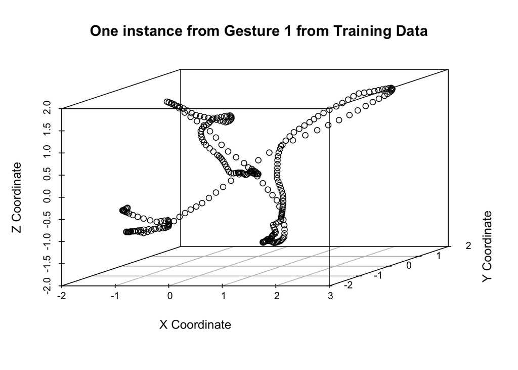

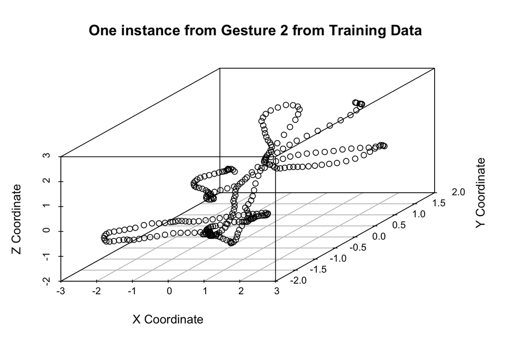

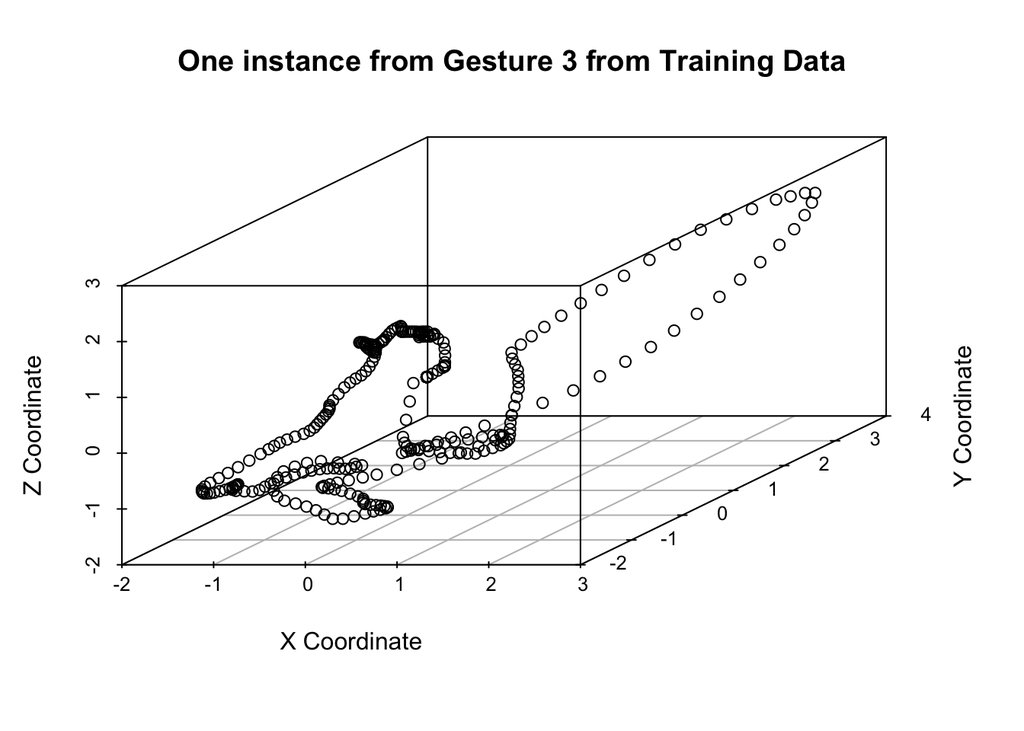

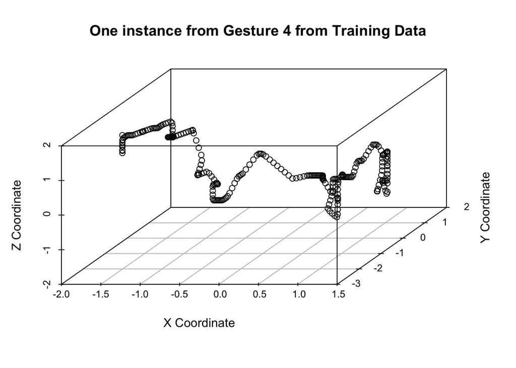

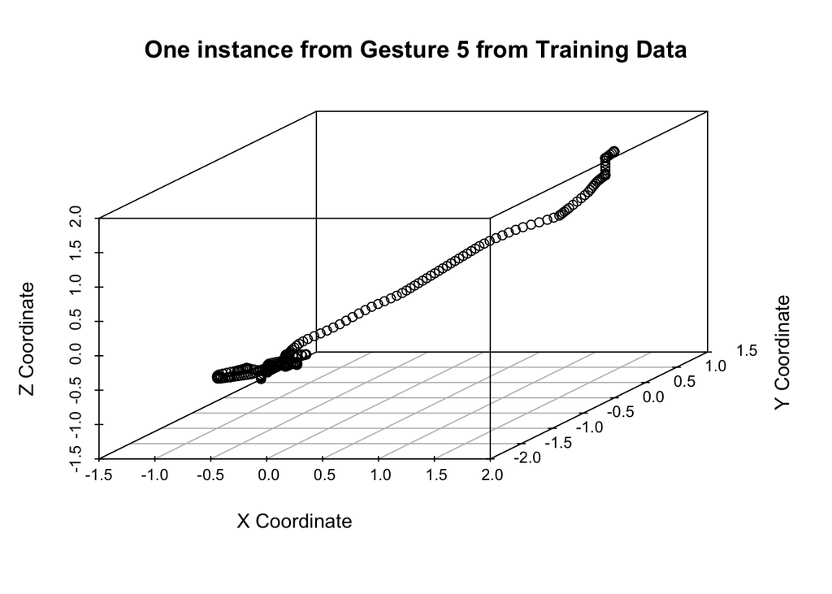

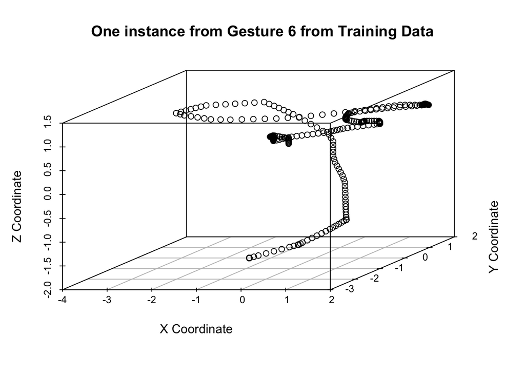

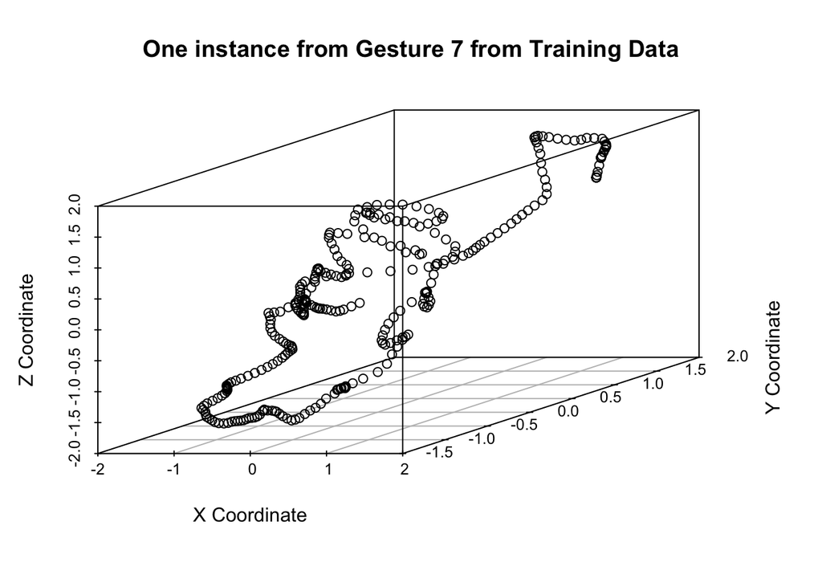

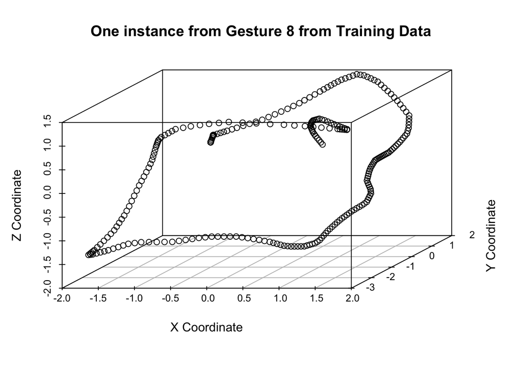

**2.2. Task 1 b):**

```
##  'crossdist' num [1:122, 1:437] 41.2 59.1 74.3 90.6 103.5 ...
##  - attr(*, "dimnames")=List of 2
##   ..$ : NULL
##   ..$ : NULL
##  - attr(*, "method")= chr "Euclidean"
##  - attr(*, "call")= language dist(x = train_gesture1, y = test_gesture1)
```

```
##  'crossdist' num [1:108, 1:452] 33.6 46.8 70.8 89.3 110.6 ...
##  - attr(*, "dimnames")=List of 2
##   ..$ : NULL
##   ..$ : NULL
##  - attr(*, "method")= chr "Euclidean"
##  - attr(*, "call")= language dist(x = train_gesture2, y = test_gesture2)
```

```
##  'crossdist' num [1:106, 1:454] 38.3 47.9 56 80.9 104.8 ...
##  - attr(*, "dimnames")=List of 2
##   ..$ : NULL
##   ..$ : NULL
##  - attr(*, "method")= chr "Euclidean"
##  - attr(*, "call")= language dist(x = train_gesture3, y = test_gesture3)
```

```
##  'crossdist' num [1:110, 1:450] 28.8 50.4 71.5 89.8 111.9 ...
##  - attr(*, "dimnames")=List of 2
##   ..$ : NULL
##   ..$ : NULL
##  - attr(*, "method")= chr "Euclidean"
##  - attr(*, "call")= language dist(x = train_gesture4, y = test_gesture4)
```

```
##  'crossdist' num [1:127, 1:433] 13.3 35.2 49.6 67.2 89 ...
##  - attr(*, "dimnames")=List of 2
##   ..$ : NULL
##   ..$ : NULL
##  - attr(*, "method")= chr "Euclidean"
##  - attr(*, "call")= language dist(x = train_gesture5, y = test_gesture5)
```

```
##  'crossdist' num [1:111, 1:449] 40.1 51.1 66.4 73.2 94.8 ...
##  - attr(*, "dimnames")=List of 2
##   ..$ : NULL
##   ..$ : NULL
##  - attr(*, "method")= chr "Euclidean"
##  - attr(*, "call")= language dist(x = train_gesture6, y = test_gesture6)
```

```
##  'crossdist' num [1:112, 1:447] 25.1 32.4 52 73.2 86.6 ...
##  - attr(*, "dimnames")=List of 2
##   ..$ : NULL
##   ..$ : NULL
##  - attr(*, "method")= chr "Euclidean"
##  - attr(*, "call")= language dist(x = train_gesture7, y = test_gesture7)
```

```
##  'crossdist' num [1:100, 1:460] 46.4 48.4 71.9 89.8 104.2 ...
##  - attr(*, "dimnames")=List of 2
##   ..$ : NULL
##   ..$ : NULL
##  - attr(*, "method")= chr "Euclidean"
##  - attr(*, "call")= language dist(x = train_gesture8, y = test_gesture8)
```

**3. APPENDIX**

**3.1. Task 1 a):**

**3.1.1. Code for Figure 1:**

require(‘scatterplot3d’)

require(‘class’)

traindata_X=‘/Users/zehra/Desktop/IE582/Homework3/UWave_TRAIN/uWaveGestureLibrary_X_TRAIN’

traindataX <- as.matrix(read.table(traindata_X))

trainclass=traindataX[,1]

traindata_Y=‘/Users/zehra/Desktop/IE582/Homework3/UWave_TRAIN/uWaveGestureLibrary_Y_TRAIN’

traindataY <- as.matrix(read.table(traindata_Y))

trainclass=traindataY[,1]

traindata_Z=‘/Users/zehra/Desktop/IE582/Homework3/UWave_TRAIN/uWaveGestureLibrary_Z_TRAIN’

traindataZ <- as.matrix(read.table(traindata_Z))

trainclass=traindataZ[,1]

**3.1.2.For gesture 1:**

traindata_X_gesture1=traindataX[traindataX[,1]==1,]

traindata_X_gesture1=traindata_X_gesture1[,2:ncol(traindata_X_gesture1)]

tlength=ncol(traindata_X_gesture1)

noftimeseries=nrow(traindata_X_gesture1)

df_traindata_X_gesture1=data.frame(traindata_X_gesture1)

df_traindata_X_gesture1=cumsum(df_traindata_X_gesture1)

traindata_Y_gesture1=traindataY[traindataY[,1]==1,]

traindata_Y_gesture1=traindata_Y_gesture1[,2:ncol(traindata_Y_gesture1)]

tlength=ncol(traindata_Y_gesture1)

noftimeseries=nrow(traindata_Y_gesture1)

df_traindata_Y_gesture1=data.frame(traindata_Y_gesture1)

df_traindata_Y_gesture1=cumsum(df_traindata_Y_gesture1)

traindata_Z_gesture1=traindataZ[traindataZ[,1]==1,]

traindata_Z_gesture1=traindata_Z_gesture1[,2:ncol(traindata_Z_gesture1)]

tlength=ncol(traindata_Z_gesture1)

noftimeseries=nrow(traindata_Z_gesture1)

df_traindata_Z_gesture1=data.frame(traindata_Z_gesture1)

df_traindata_Z_gesture1=cumsum(df_traindata_Z_gesture1)

traindatacombined_gesture1=cbind(df_traindata_X_gesture1,df_traindata_Y_gesture1,df_traindata_Z_gesture1)

traindatacombined_gesture1=as.matrix.data.frame(traindatacombined_gesture1)

**3.1.3.For other gestures:**

For each gesture, I choose the class. As in below, I chose the Gesture 2.

traindata_X_gesture1=traindataX[traindataX[,1]==2,]

Then I modified data names and repeat steps in codes.

**3.2. Task 1 b):**

For train data gesture 1

train_gesture1=cbind(df_traindata_X_gesture1,df_traindata_Y_gesture1,df_traindata_Z_gesture1)

testdata_X=‘/Users/zehra/Desktop/IE582/Homework3/UWave_TEST/uWaveGestureLibrary_X_TEST’

testdataX <- as.matrix(read.table(testdata_X))

testclass=testdataX[,1]

testdata_Y=‘/Users/zehra/Desktop/IE582/Homework3/UWave_TEST/uWaveGestureLibrary_Y_TEST’

testdataY <- as.matrix(read.table(testdata_Y))

testclass=testdataY[,1]

testdata_Z=‘/Users/zehra/Desktop/IE582/Homework3/UWave_TEST/uWaveGestureLibrary_Z_TEST’

testdataZ <- as.matrix(read.table(testdata_Z))

testclass=testdataZ[,1]

For test data gesture 1

testdata_X_gesture1=testdataX[testdataX[,1]==1,]

testdata_X_gesture1=testdata_X_gesture1[,2:ncol(testdata_X_gesture1)]

tlength=ncol(testdata_X_gesture1)

noftimeseries=nrow(testdata_X_gesture1)

df_testdata_X_gesture1=data.frame(testdata_X_gesture1)

df_testdata_X_gesture1=cumsum(df_testdata_X_gesture1)

testdata_Y_gesture1=testdataY[testdataY[,1]==1,]

testdata_Y_gesture1=testdata_Y_gesture1[,2:ncol(testdata_Y_gesture1)]

tlength=ncol(testdata_Y_gesture1)

noftimeseries=nrow(testdata_Y_gesture1)

df_testdata_Y_gesture1=data.frame(testdata_Y_gesture1)

df_testdata_Y_gesture1=cumsum(df_testdata_Y_gesture1)

testdata_Z_gesture1=testdataZ[testdataZ[,1]==1,]

testdata_Z_gesture1=testdata_Z_gesture1[,2:ncol(testdata_Z_gesture1)]

tlength=ncol(testdata_Z_gesture1)

noftimeseries=nrow(testdata_Z_gesture1)

df_testdata_Z_gesture1=data.frame(testdata_Z_gesture1)

df_testdata_Z_gesture1=cumsum(df_testdata_Z_gesture1)

test_gesture1=cbind(df_testdata_X_gesture1,df_testdata_Y_gesture1,df_testdata_Z_gesture1)

train_gesture1=as.matrix(train_gesture1)

test_gesture1=as.matrix(test_gesture1)

require(‘proxy’)

distance_gesture1=dist(train_gesture1, test_gesture1)

str(distance_gesture1)

**3.2.1. For other gestures:**

I chose the class and modified codes.

**3.3. Task 2:**

penalized (response, penalized, unpenalized, lambda1=0, lambda2=0, positive = FALSE, data, fusedl=TRUE, standardize = FALSE)